# Lecture 3: Logistic Regression

## Logistic Regression

Logistic Regression is the technique of choice when modeling a binary outcome. Similar to linear regression, logistic regression often used as inferential technique in addition to being a good first choice to many machine learning classification tasks. In this session we are going to explore some applications of logistic regression to real world data.

### Data

We are going to look at data from the National Election study, a pre-election (USA) poll measuring voter preferences along with information on age, gender, race, income, religion, marital status, education level, and occupation. The data contains polling information on every presidential election from 1948 to 2002.

```r
# Load the required libraries
library(tidyverse)


# load the data

nes <- readr::read_csv(paste0(here::here(),"/nes_data.csv"))


nes %>% head %>%
  DT::datatable(caption = "First 6 observations",
                options = list(scrollX = T))
```

|  | year | age | gender | race | educ1 | income_num | income | occup1 | union | religion | marital_status | father_party | mother_party | vote | presvote | presvote_2party |
| --- | --- | --- | --- | --- | --- | --- | --- | --- | --- | --- | --- | --- | --- | --- | --- | --- |
| 1 | 1948 |  | 1. male | 1. white | 1. grade school of less (0-8 grades) | 3 | 3. 34 to 67 percentile |  | 1. yes, someone (1948: head) in househol | 1. protestant |  |  |  | 2. yes, voted | 1. democrat | 1. democrat |
| 2 | 1948 |  | 2. female | 1. white | 2. high school (12 grades or fewer, incl | 5 | 5. 96 to 100 percentile |  | 2. no, no one in the household belongs t | 1. protestant |  |  |  | 2. yes, voted | 2. republican | 2. republican |
| 3 | 1948 |  | 2. female | 1. white | 2. high school (12 grades or fewer, incl | 4 | 4. 68 to 95 percentile |  | 2. no, no one in the household belongs t | 2. catholic (roman catholic) |  |  |  | 2. yes, voted | 1. democrat | 1. democrat |
| 4 | 1948 |  | 2. female | 1. white | 3. some college(13 grades or more,but no | 5 | 5. 96 to 100 percentile |  | 2. no, no one in the household belongs t | 1. protestant |  |  |  | 2. yes, voted | 2. republican | 2. republican |
| 5 | 1948 |  | 1. male | 1. white | 3. some college(13 grades or more,but no | 4 | 4. 68 to 95 percentile |  | 2. no, no one in the household belongs t | 2. catholic (roman catholic) |  |  |  | 2. yes, voted | 1. democrat | 1. democrat |
| 6 | 1948 |  | 2. female | 1. white | 2. high school (12 grades or fewer, incl | 5 | 5. 96 to 100 percentile |  | 2. no, no one in the household belongs t | 1. protestant |  |  |  | 2. yes, voted | 2. republican | 2. republican |

## Introduction to Logistic regression

Given a binary variable $y$, we want to model the probability that $y=1$ as:

$$Pr(y_i=1) = logit^{-1}(X_i\beta)$$
we assume that the $y_i$ are independent of one another.

### The $logit^{-1}$ function

The $logit^{-1}$ function is defined as:

$$logit^{-1}(x) = \frac{1}{1+e^{-x}}$$

This function takes as input any continuous x value between $(-\infty, \infty)$ and transforms it to the scale $(0,1)$.

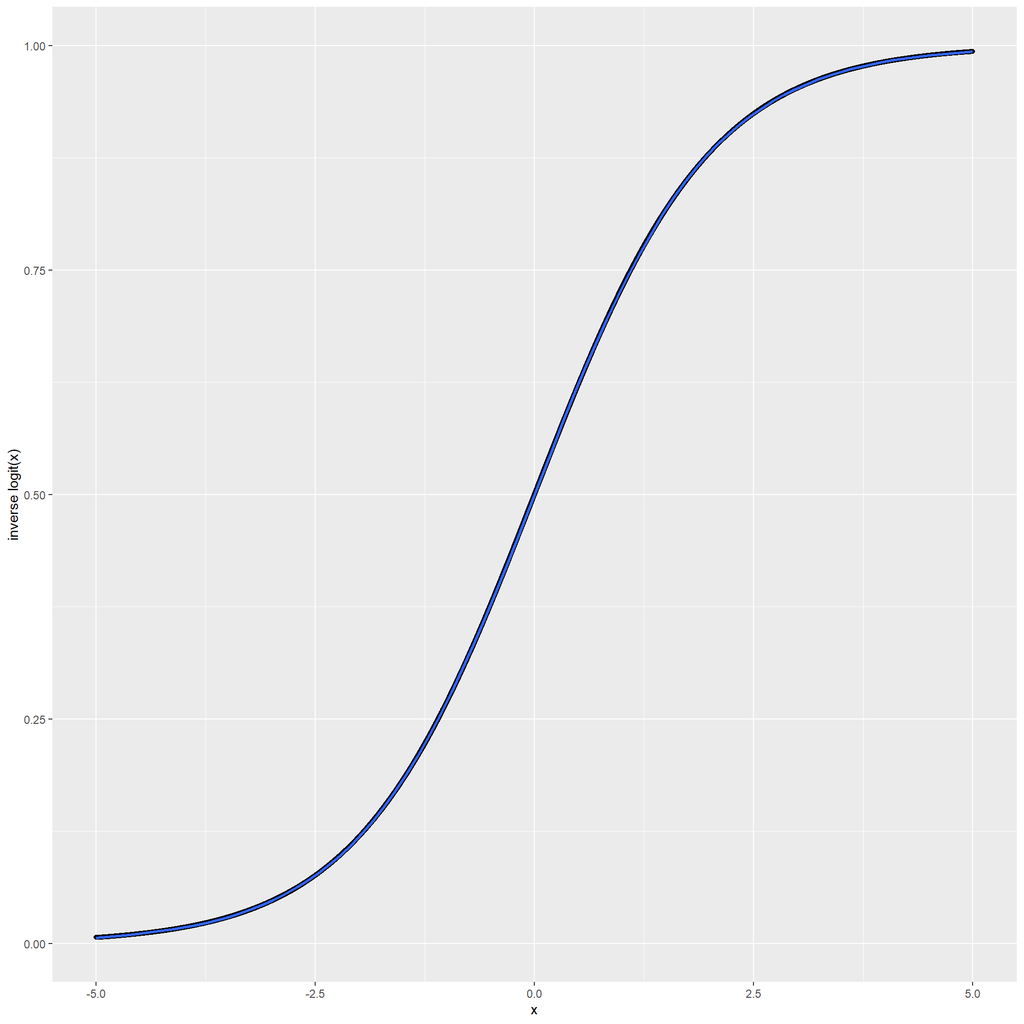

```r
continuous_data <- tibble(x = seq(-5, 5, length.out = 10000))

inv_logit_function <- function(x) {

  inv_logit <- 1/(1 + exp(-x))

  return(inv_logit)
}

continuous_data <- continuous_data %>%
  mutate(inv_logit_x = inv_logit_function(x))

continuous_data %>%
  ggplot(aes(x, inv_logit_x)) +
  geom_point() +
  geom_smooth() +
  ylab("inverse logit(x)")
```

The logit function is given by:

$$logit = \log\left(\frac{x}{1-x}\right)$$

The $logit$ function maps inputs from $(0,1)$ to $(-\infty, \infty)$. If $Pr(y_i = 1) = logit^{-1}(X_i\beta) = p_i$, then $logit(p_i) = X_i\beta$

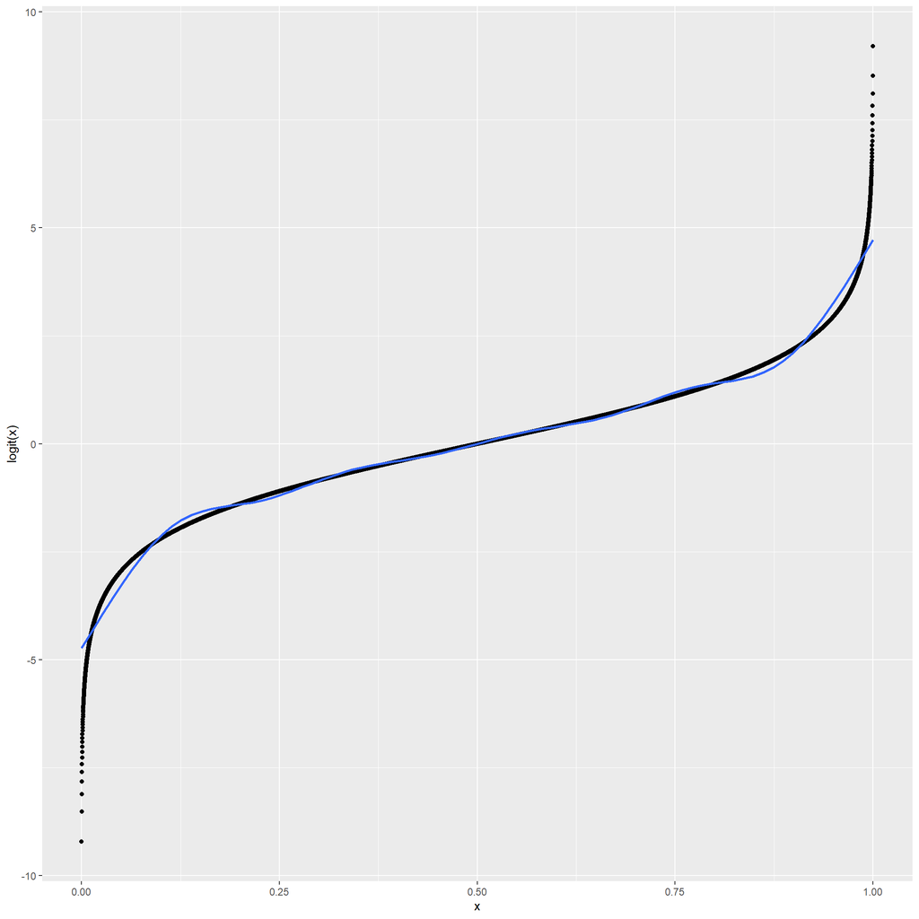

```r
continuous_data <- tibble(x = seq(0.0001, 0.9999, length.out = 10000))

logit_function <- function(x) {

  logit_x <- log(x/(1 - x))

  return(logit_x)
}

continuous_data <- continuous_data %>%
  mutate(logit_x = logit_function(x))

continuous_data %>%
  ggplot(aes(x, logit_x)) +
  geom_point() +
  geom_smooth() +
  ylab("logit(x)")
```

The inverse logit function is natural to work with since it maps linear predictions ($X\beta$) to probabilities.

Let’s fit a simple model to our data with income as the input feature and voting preference as the output feature. We will look specifically at the year 1992 (Bush vs. Clinton)

```r
# filter the data for 1992
nes_1992 <- nes %>%
  filter(year == 1992)

# simple count of the voting preference variables
nes_1992 %>%
  count(presvote, presvote_2party) %>%
  knitr::kable()
```

| presvote | presvote_2party | n |
| --- | --- | --- |
| 1. democrat | 1. democrat | 765 |
| 2. republican | 2. republican | 539 |
| 3. major third party cand (wallace 1968/ | NA | 194 |
| NA | NA | 449 |

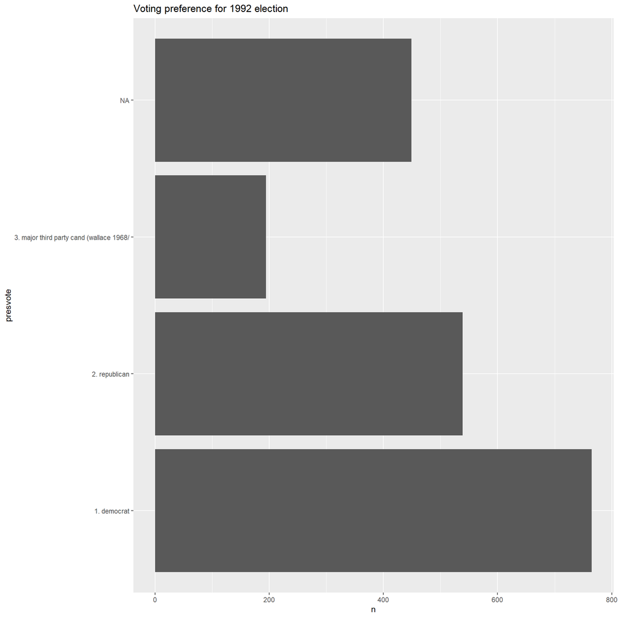

```r
# Bar plot of the voting preference variable
nes_1992 %>%
  count(presvote) %>%
  ggplot(aes(presvote, n)) +
  geom_bar(stat = 'identity') +
  coord_flip() +
  ggtitle("Voting preference for 1992 election")
```

```r
# Convert the 2 vote character variable to a binary variable
nes_1992 <- nes_1992 %>%
  mutate(presvote_binary = ifelse(presvote_2party == '2. republican', 1, 0)) %>%
  filter(!is.na(presvote_binary))

# A quick check to make sure the variable we created is
# doing what we intended it to do
nes_1992 %>%
  count(presvote_binary, presvote_2party )
```

| presvote_binary | presvote_2party | n |
| --- | --- | --- |
| 0 | 1. democrat | 765 |
| 1 | 2. republican | 539 |

```r
# Fitting a simple logistic regression model
simple_model <- glm(presvote_binary ~ income_num, data = nes_1992,
                    family = binomial(link = "logit"))

# Display a summary of the model fit
summary(simple_model)
```

```
##
## Call:
## glm(formula = presvote_binary ~ income_num, family = binomial(link = "logit"),
##     data = nes_1992)
##
## Deviance Residuals:
##     Min       1Q   Median       3Q      Max
## -1.2699  -1.0162  -0.8998   1.2152   1.6199
##
## Coefficients:
##             Estimate Std. Error z value Pr(>|z|)
## (Intercept)  -1.3017     0.1828  -7.122 1.06e-12 ***
## income_num    0.3033     0.0551   5.505 3.69e-08 ***
## ---
## Signif. codes:  0 '***' 0.001 '**' 0.01 '*' 0.05 '.' 0.1 ' ' 1
##
## (Dispersion parameter for binomial family taken to be 1)
##
##     Null deviance: 1655.0  on 1221  degrees of freedom
## Residual deviance: 1623.5  on 1220  degrees of freedom
##   (82 observations deleted due to missingness)
## AIC: 1627.5
##
## Number of Fisher Scoring iterations: 4
```

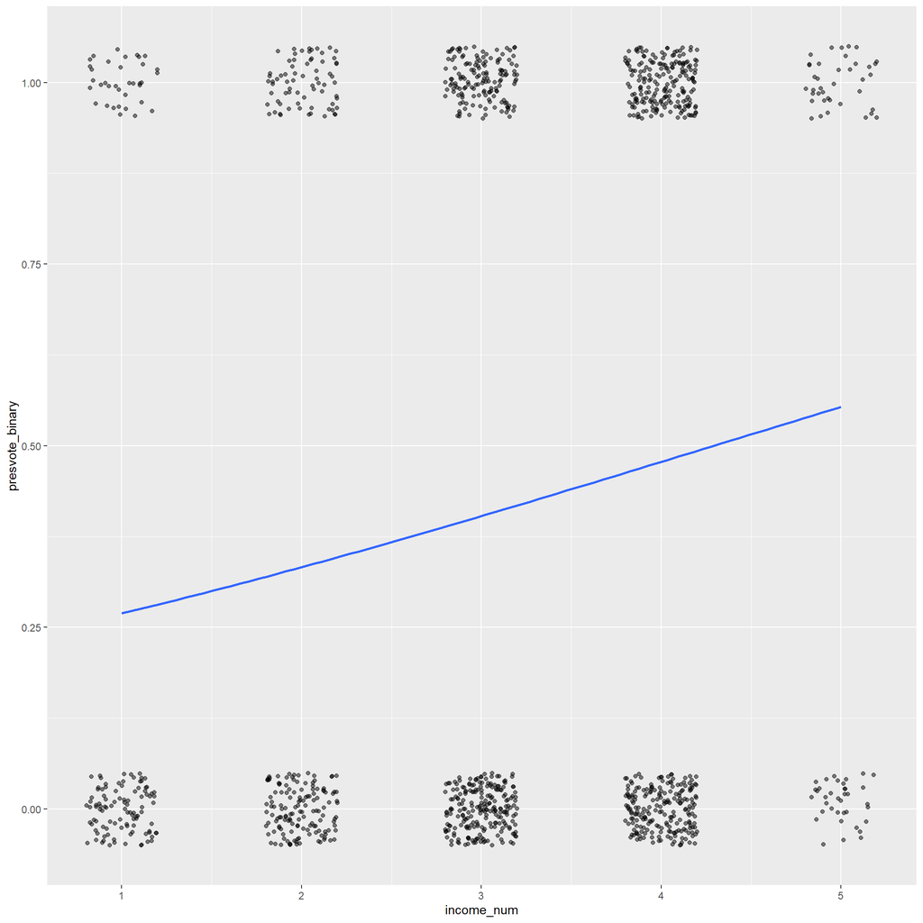

```r
# A plot of the fitted logistic regression line
ggplot(nes_1992, aes(x=income_num, y=presvote_binary)) +
  geom_jitter(alpha = .5,width = .2, height = .05) +
  stat_smooth(method="glm",
              method.args=list(family="binomial"), se=FALSE)
```

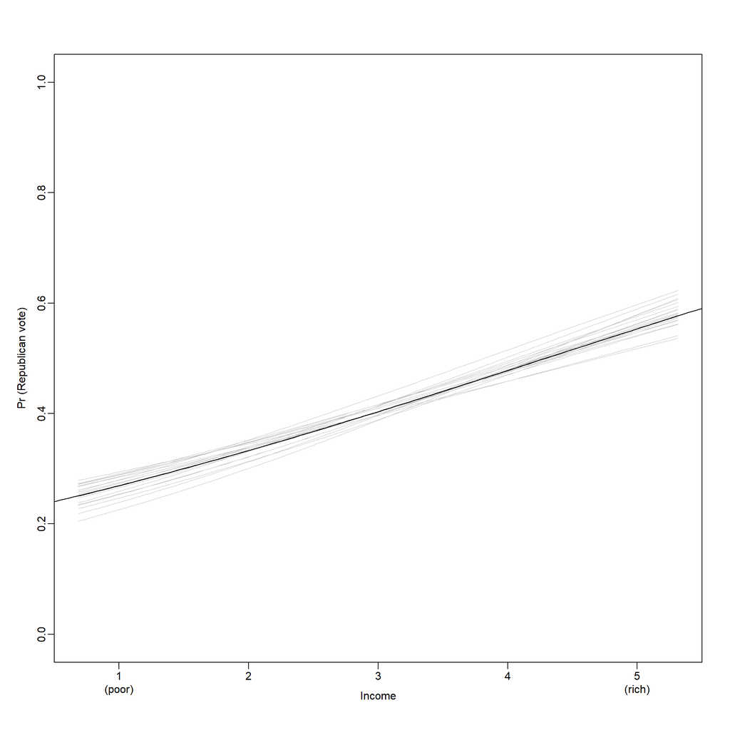

```r
# Load the applied regression modeling package
library(arm)

# random draws from the slope and intercept
sim1 <- sim(simple_model)


# From Applied Regression modeling

curve (invlogit(simple_model$coef[1] + simple_model$coef[2]*x), .5, 5.5, ylim=c(-.01,1.01),
         xlim=c(.5,5.5), xaxt="n", xaxs="i", mgp=c(2,.5,0),
         ylab="Pr (Republican vote)", xlab="Income", lwd=1)
  for (j in 1:20){
    curve (invlogit(sim1@coef[j,1] + sim1@coef[j,2]*x), col="gray", lwd=.5, add=T)
  }
  curve (invlogit(simple_model$coef[1] + simple_model$coef[2]*x), add=T)
  axis (1, 1:5, mgp=c(2,.5,0))
  mtext ("(poor)", 1, 1.5, at=1, adj=.5)
  mtext ("(rich)", 1, 1.5, at=5, adj=.5)
```

```r
  points (jitter (nes_1992$income, .5), jitter (nes_1992$presvote_binary, .08), pch=20, cex=.1)
```

```
## Error in jitter(nes_1992$income, 0.5): 'x' must be numeric
```

## Coefficient interpretation

It’s natural to want to interpret regression coefficients. For example, if our fitted model was a linear regression model we could interpret the coefficient as the average change in the output for a 1 unit change in income. So a change in income from 1 to 2 would increase the outcome by 0.303, and a change in income from 4 to 5 would increase the outcome by 0.303. However, the inverse logistic function is not a straight line.

For example

```r
# logit of .5
logit_function(.5)
```

```
## [1] 0
```

```r
# logit of .6
logit_function(.6)
```

```
## [1] 0.4054651
```

So, going from a probability of 50% to 60% is equivalent to going from 0 to .4 on the logistic scale.

```r
# logit of .90
logit_function(.90)
```

```
## [1] 2.197225
```

```r
# logit of .93
logit_function(.93)
```

```
## [1] 2.586689
```

Going from a probability of 90% to 93% is equivalent to going from 2.2 to 2.6 on the logistic scale. Any particular change on the logit scale is compressed at the ends of the probability scale, which is needed to keep probabilities bounded between 0 and 1.

The curve in the logistic function means we need to choose where to evaluate changes in the input.

- For interpreting the *intercept*, we usually want to evaluate the model when the input is equal to zero. That doesn’t really make sense here since the range of our input goes from 1-5. A better starting point is either in the most common category or the mean of the input.

```r
mean_income <- mean(nes_1992$income_num, na.rm = TRUE)

intercept <- coef(simple_model)[1]
slope <- coef(simple_model)[2]

inv_logit_function(intercept + mean_income*slope)
```

```
## (Intercept)
##    0.408194
```

So the probability of supporting Bush in 1992 for someone with an average income is 41%.

- The slope coefficient is 0.303, meaning a difference of 1 in the income scale corresponds to a difference of 0.303 in the logit probability scale.
  - We can evaluate how the probability changes with a one unit difference in x near the mean value we examined above.

```r
inv_logit_function(intercept + 3*slope) - inv_logit_function(intercept + 2*slope)
```

```
## (Intercept)
##  0.07038475
```

Going from an income of 2 to an income of 3 increases the probability of support for Bush by 7%.

### The “divide by 4 rule”

The logistic curve is steepest at its center, at which point:

$$\alpha + \beta x = 0$$

so

$$logit^{-1}(\alpha + \beta x ) = .5$$

The slope of the curve—the derivative of the logistic function is maximized at this point and attains the value

$$\frac{\beta e^{\alpha + \beta x}}{(1 + \beta e^{\alpha + \beta x})^2}$$

$$\frac{\beta e^{0}}{(1 + \beta e^{0})^2} = \beta/4$$

Therefore, $\beta/4$ is the maximum difference in $Pr(y = 1)$ corresponding to a 1 unit difference in x.

So in our example,$0.303/4$ = 0.076.

We can take logistic regression coefficients (other than the constant term) and divide them by 4 to get an upper bound of the predictive difference corresponding to a unit difference in x. This upper bound is a reasonable approximation near the midpoint of the logistic curve, where probabilities are close to 0.5.

## Odds ratios

A common method of interpreting logistic regression coefficients is in terms of odds ratios (especially in medicine!)

If two outcomes have probability of occuring $p$ and $p-1$, then we call

$$\frac{p}{1-p}$$

We can define the ratio of two odds as

$$OR = (p_1/(1-p_1))/(p_2/(1-p_2))$$
is called the Odds Ratio. For example, a change in odds from $p_1 = 1/3 = .33$ to $p_2 = 1/2 = .5$ is

```r
calc_or <- function(p1, p2) {

  or <- (p1/(1-p1)) / (p2/(1-p2))

  return(or)

}

p1 <- 1/3
p2 <- 1/2
calc_or(p1, p2)
```

```
## [1] 0.5
```

An advantage of working with odds ratios instead of probabilities is that it is possible to keep scaling up odds ratios indefinitely without running into the boundary points of 0 and 1

We can exponentiate the logistic regression coefficients and interpret them as odds ratios. Let’s illustrate this with an example model with only one predictor

$$log\left(\frac{Pr(y=1|x)}{Pr(y=0|x)} \right) = \alpha + \beta x$$

If we add 1 to $x$ in both sides of the equation above, this has the effect of add $\beta$. Exponentiating both sides, the odds are then multiplied by $e^\beta$. So in our example $\beta =$ 0.303, so a 1 unit change in x is equivalent to a multiplicative change of $e^{.303}$ = 1.35 in the odds.

### Simple example of odds ratios

Odds ratios are a weird concept to understand, but they show up a lot in literature and in industry so they are important to understand. Let’s say that a public health organization implemented an intervention to encourage people to get the flu shot. They randomly divided 200 people into 2 groups of 100. One group received an targeted intervention and the other did not. They followed the two groups for a month and then counted the number in each group that got the flu shot. The result was the following data

```r
intervention <- matrix(c(55, 45, 35, 65), ncol = 2)

colnames(intervention) <- c("No Intervention", "Intervention")
rownames(intervention) <- c("No Flu shot", "Flu shot")
intervention
```

```
##             No Intervention Intervention
## No Flu shot              55           35
## Flu shot                 45           65
```

The odds of a flu shot in the intervention group is

$$65/(65 + 35)/35/(35+65) = 1.86$$

while the odds of a flu shot in the non intervention group is

$$45/(45 + 55)/55/(55+45) = 0.82$$

This gives an odds ratio of 1.86/0.82 = 2.27. This is an interpretted as the intervention group has 2.27 times the odds of getting the flu shot compared to the non-intervention group. In general

- An OR > 1 means an increase in the odds
- An OR < 1 means a decrease in the odds
- An OR of 1 means no difference in the odds.

When doing a statistical hypothesis test, the null hypothesis is typically that $OR = 1$ and the alternative hypothesis is $OR \neq 1$.

### One more example with our data

Let’s look at differences in gender for supporting either Bush or Clinton in 1992.

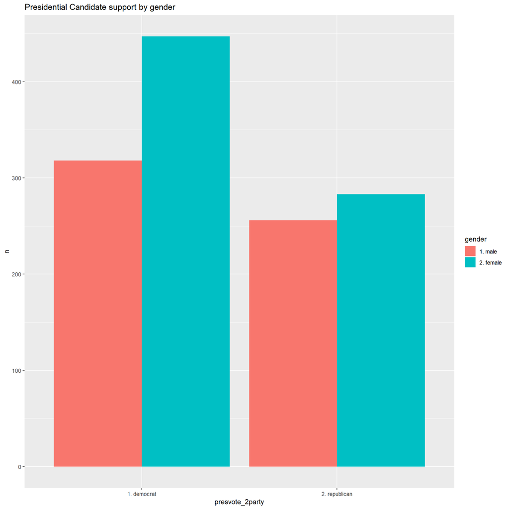

```r
nes_1992 %>%
  count(gender, presvote_2party ) %>%
  ggplot(aes(presvote_2party, n, fill =gender )) +
  geom_bar(stat = "identity", position='dodge') +
  ggtitle("Presidential Candidate support by gender")
```

```r
table(nes_1992$gender, nes_1992$presvote_2party)
```

```
##
##             1. democrat 2. republican
##   1. male           318           256
##   2. female         447           283
```

It seems that females tend to support the republican candidate less often. Let’s calculate the odds ratio

```r
tab <- table(nes_1992$gender, nes_1992$presvote_2party)
knitr::kable(tab)
```

|  | 1. democrat | 2. republican |
| --- | --- | --- |
| 1. male | 318 | 256 |
| 2. female | 447 | 283 |

```r
female_republican_oods <- (tab[2,2]/(tab[2,2] + tab[2,1]))/(tab[2,1]/(tab[2,2] + tab[2,1]) )

male_republican_oods <- (tab[1,2]/(tab[1,2] + tab[1,1]))/(tab[1,1]/(tab[1,1] + tab[1,2]) )


or <- female_republican_oods/male_republican_oods


gender_model <-  glm(presvote_binary ~ gender, data = nes_1992,
                   family = binomial(link = "logit"))



print(female_republican_oods)
```

```
## [1] 0.6331096
```

```r
print(male_republican_oods)
```

```
## [1] 0.8050314
```

```r
print(or)
```

```
## [1] 0.7864409
```

```r
summary(gender_model)
```

```
##
## Call:
## glm(formula = presvote_binary ~ gender, family = binomial(link = "logit"),
##     data = nes_1992)
##
## Deviance Residuals:
##     Min       1Q   Median       3Q      Max
## -1.0868  -0.9904  -0.9904   1.2708   1.3767
##
## Coefficients:
##                 Estimate Std. Error z value Pr(>|z|)
## (Intercept)     -0.21687    0.08397  -2.583   0.0098 **
## gender2. female -0.24024    0.11323  -2.122   0.0339 *
## ---
## Signif. codes:  0 '***' 0.001 '**' 0.01 '*' 0.05 '.' 0.1 ' ' 1
##
## (Dispersion parameter for binomial family taken to be 1)
##
##     Null deviance: 1768.4  on 1303  degrees of freedom
## Residual deviance: 1763.9  on 1302  degrees of freedom
## AIC: 1767.9
##
## Number of Fisher Scoring iterations: 4
```

```r
coef(gender_model)[2]
```

```
## gender2. female
##      -0.2402378
```

```r
exp(coef(gender_model)[2])
```

```
## gender2. female
##       0.7864409
```

Using the $2\times 2$ contingency table to calculate the odds ratio gives us the same result as using logistic regression to calculate the OR.

## Evaluating the performance of a logistic regression

So far we have looked at the output of a logistic regression model as a probability. In a predictive setting, we often want to use these probabilities to make some kind of decision. That is, we want to use the probabilities classify the output into 1 of 2 labels. In our running example, we may want to build a model to predict which candidate a potential voter will vote for and use that information to target people for donations.

If we use our model so far, we could make one of two potential errors:

- Predict that a voter will vote for Bush when they voted for Clinton
- Predict that a voter will vote for Clinton when they voted for Bush

Let’s continue on with our example, by adding a few more predictor variables and try to use it to determine who a potential voter will vote for (in 1992).

```r
nes_1992 <- nes_1992%>% mutate(age_group = case_when (
  age < 35 ~ "18-35",
  age <55 ~ "35-55",
  age < 75 ~ "55-75",
  TRUE ~ "76+"
),age_group = factor(age_group, levels = c("35-55",
                                    "18-35",
                                    "55-75",
                                    "76+")))
nes_1992 <- nes_1992 %>%
  mutate(education_num = as.numeric(stringr::str_sub(educ1, 1, 1)))

# select the variables we wish to examine
nes_1992 <- nes_1992 %>%
  dplyr::select(presvote_binary , race, gender, age, age_group, marital_status, income, religion, occup1,
                education_num)

# remove missing values
nes_1992 <- nes_1992 %>%
  filter(complete.cases(nes_1992))

# split data into training and testing sets

set.seed(13453)
n <- nrow(nes_1992)
training_size <- .8
split <- sample(1:nrow(nes_1992), floor(n*training_size), replace = F)

train_df <- nes_1992 %>%
  slice(split)

test_df <- nes_1992 %>%
  slice(-split)
```

### Starting with a basic model

We start with a basic model only including income

```r
basic_model <- glm(presvote_binary ~ income, data = train_df, family = binomial)

summary(basic_model)
```

```
##
## Call:
## glm(formula = presvote_binary ~ income, family = binomial, data = train_df)
##
## Deviance Residuals:
##     Min       1Q   Median       3Q      Max
## -1.1774  -1.0072  -0.8799   1.1909   1.6259
##
## Coefficients:
##                               Estimate Std. Error z value Pr(>|z|)
## (Intercept)                    -1.0116     0.2384  -4.244  2.2e-05 ***
## income2. 17 to 33 percentile    0.2624     0.2918   0.899 0.368566
## income3. 34 to 67 percentile    0.5972     0.2679   2.229 0.025819 *
## income4. 68 to 95 percentile    0.9799     0.2637   3.716 0.000202 ***
## income5. 96 to 100 percentile   1.0116     0.3581   2.825 0.004731 **
## ---
## Signif. codes:  0 '***' 0.001 '**' 0.01 '*' 0.05 '.' 0.1 ' ' 1
##
## (Dispersion parameter for binomial family taken to be 1)
##
##     Null deviance: 1221.2  on 901  degrees of freedom
## Residual deviance: 1197.0  on 897  degrees of freedom
## AIC: 1207
##
## Number of Fisher Scoring iterations: 4
```

We can look at different reference levels of income if easy interpretation is important

```r
train_df <- train_df %>%
  mutate(income_refact = factor(income,
                         levels = c("3. 34 to 67 percentile",
                                    "1. 0 to 16 percentile",
                                    "2. 17 to 33 percentile",
                                    "4. 68 to 95 percentile",
                                    "5. 96 to 100 percentile")))
basic_model2 <- glm(presvote_binary ~ income_refact, data = train_df, family = binomial)

summary(basic_model2)
```

```
##
## Call:
## glm(formula = presvote_binary ~ income_refact, family = binomial,
##     data = train_df)
##
## Deviance Residuals:
##     Min       1Q   Median       3Q      Max
## -1.1774  -1.0072  -0.8799   1.1909   1.6259
##
## Coefficients:
##                                      Estimate Std. Error z value Pr(>|z|)
## (Intercept)                           -0.4144     0.1223  -3.388 0.000704 ***
## income_refact1. 0 to 16 percentile    -0.5972     0.2679  -2.229 0.025819 *
## income_refact2. 17 to 33 percentile   -0.3348     0.2080  -1.609 0.107556
## income_refact4. 68 to 95 percentile    0.3827     0.1663   2.301 0.021399 *
## income_refact5. 96 to 100 percentile   0.4144     0.2939   1.410 0.158535
## ---
## Signif. codes:  0 '***' 0.001 '**' 0.01 '*' 0.05 '.' 0.1 ' ' 1
##
## (Dispersion parameter for binomial family taken to be 1)
##
##     Null deviance: 1221.2  on 901  degrees of freedom
## Residual deviance: 1197.0  on 897  degrees of freedom
## AIC: 1207
##
## Number of Fisher Scoring iterations: 4
```

```r
# remove the refactored variable

train_df <- train_df %>%
  select(-income_refact)
```

```
## Error in select(., -income_refact): unused argument (-income_refact)
```

### Adding in a second feature

```r
basic_model3 <- glm(presvote_binary ~ income + education_num, data = train_df, family = binomial)

summary(basic_model3)
```

```
##
## Call:
## glm(formula = presvote_binary ~ income + education_num, family = binomial,
##     data = train_df)
##
## Deviance Residuals:
##     Min       1Q   Median       3Q      Max
## -1.2147  -1.0720  -0.8602   1.2600   1.6858
##
## Coefficients:
##                               Estimate Std. Error z value Pr(>|z|)
## (Intercept)                   -1.28423    0.28666  -4.480 7.47e-06 ***
## income2. 17 to 33 percentile   0.20136    0.29427   0.684  0.49382
## income3. 34 to 67 percentile   0.47236    0.27759   1.702  0.08882 .
## income4. 68 to 95 percentile   0.81286    0.28059   2.897  0.00377 **
## income5. 96 to 100 percentile  0.77775    0.38265   2.033  0.04210 *
## education_num                  0.13968    0.08063   1.732  0.08319 .
## ---
## Signif. codes:  0 '***' 0.001 '**' 0.01 '*' 0.05 '.' 0.1 ' ' 1
##
## (Dispersion parameter for binomial family taken to be 1)
##
##     Null deviance: 1221.2  on 901  degrees of freedom
## Residual deviance: 1194.0  on 896  degrees of freedom
## AIC: 1206
##
## Number of Fisher Scoring iterations: 4
```

Adding in age

```r
basic_model4 <- glm(presvote_binary ~ income + education_num +
                      age, data = train_df, family = binomial)

summary(basic_model4)
```

```
##
## Call:
## glm(formula = presvote_binary ~ income + education_num + age,
##     family = binomial, data = train_df)
##
## Deviance Residuals:
##    Min      1Q  Median      3Q     Max
## -1.301  -1.047  -0.833   1.246   1.698
##
## Coefficients:
##                                Estimate Std. Error z value Pr(>|z|)
## (Intercept)                   -1.613136   0.403597  -3.997 6.42e-05 ***
## income2. 17 to 33 percentile   0.199810   0.294399   0.679  0.49733
## income3. 34 to 67 percentile   0.511438   0.280103   1.826  0.06787 .
## income4. 68 to 95 percentile   0.852436   0.283364   3.008  0.00263 **
## income5. 96 to 100 percentile  0.795397   0.383621   2.073  0.03814 *
## education_num                  0.158869   0.082358   1.929  0.05373 .
## age                            0.005128   0.004404   1.164  0.24424
## ---
## Signif. codes:  0 '***' 0.001 '**' 0.01 '*' 0.05 '.' 0.1 ' ' 1
##
## (Dispersion parameter for binomial family taken to be 1)
##
##     Null deviance: 1221.2  on 901  degrees of freedom
## Residual deviance: 1192.7  on 895  degrees of freedom
## AIC: 1206.7
##
## Number of Fisher Scoring iterations: 4
```

age doesn’t seem important. Let’s try looking at it a different way

```r
train_df <- train_df%>% mutate(age_group = case_when (
  age < 35 ~ "18-35",
  age <55 ~ "35-55",
  age < 75 ~ "55-75",
  TRUE ~ "76+"
),age_group = factor(age_group, levels = c("35-55",
                                    "18-35",
                                    "55-75",
                                    "76+")))

basic_model5 <- glm(presvote_binary ~ income + education_num +
                      age_group, data = train_df, family = binomial)

summary(basic_model5)
```

```
##
## Call:
## glm(formula = presvote_binary ~ income + education_num + age_group,
##     family = binomial, data = train_df)
##
## Deviance Residuals:
##     Min       1Q   Median       3Q      Max
## -1.5017  -1.0316  -0.8174   1.2212   1.7691
##
## Coefficients:
##                               Estimate Std. Error z value Pr(>|z|)
## (Intercept)                   -1.64849    0.33115  -4.978 6.42e-07 ***
## income2. 17 to 33 percentile   0.23853    0.29662   0.804 0.421305
## income3. 34 to 67 percentile   0.59500    0.28426   2.093 0.036333 *
## income4. 68 to 95 percentile   0.96119    0.28910   3.325 0.000885 ***
## income5. 96 to 100 percentile  0.96190    0.39073   2.462 0.013825 *
## education_num                  0.16714    0.08285   2.018 0.043642 *
## age_group18-35                 0.28239    0.17623   1.602 0.109065
## age_group55-75                 0.15102    0.18398   0.821 0.411733
## age_group76+                   0.75493    0.27278   2.768 0.005648 **
## ---
## Signif. codes:  0 '***' 0.001 '**' 0.01 '*' 0.05 '.' 0.1 ' ' 1
##
## (Dispersion parameter for binomial family taken to be 1)
##
##     Null deviance: 1221.2  on 901  degrees of freedom
## Residual deviance: 1185.4  on 893  degrees of freedom
## AIC: 1203.4
##
## Number of Fisher Scoring iterations: 4
```

```r
# remove age
train_df <- train_df %>%
  dplyr::select(-age)

full_model <- glm(presvote_binary ~ ., data = train_df, family = binomial)

summary(full_model)
```

```
##
## Call:
## glm(formula = presvote_binary ~ ., family = binomial, data = train_df)
##
## Deviance Residuals:
##     Min       1Q   Median       3Q      Max
## -1.7488  -0.9622  -0.4198   1.0002   2.4537
##
## Coefficients: (4 not defined because of singularities)
##                                                         Estimate Std. Error
## (Intercept)                                            -1.264790   0.510131
## race2. black                                           -2.740087   0.393469
## race3. asian                                            1.796236   0.714260
## race4. native american                                 -0.255954   0.457192
## race5. hispanic                                        -0.310303   0.412777
## gender2. female                                        -0.138433   0.178245
## age_group18-35                                          0.469474   0.207057
## age_group55-75                                         -0.002916   0.208884
## age_group76+                                            0.531897   0.336009
## marital_status2. never married                         -0.667850   0.285924
## marital_status3. divorced                              -0.692066   0.273971
## marital_status4. separated                              0.927641   0.636606
## marital_status5. widowed                                0.079409   0.304453
## marital_status7. partners/ not married (volunteered [e -0.912334   0.608432
## income2. 17 to 33 percentile                            0.069919   0.330020
## income3. 34 to 67 percentile                            0.187290   0.329196
## income4. 68 to 95 percentile                            0.484046   0.347368
## income5. 96 to 100 percentile                           0.477393   0.459477
## religion2. catholic (roman catholic)                   -0.850663   0.186413
## religion3. jewish                                      -2.383528   0.640097
## religion4. other and none (also includes dk pref       -1.963484   0.292686
## occup12. clerical and sales workers                     0.295934   0.224776
## occup13. skilled, semi-skilled and service wor          0.318523   0.234807
## occup14. laborers, except farm                         -1.313834   0.821745
## occup15. farmers,farm managers,farm laborers &          0.979894   0.480033
## occup16. homemkrs(1972-92:7 in vcf0116,4 in vc          0.450194   0.300050
## education_num                                           0.399063   0.107627
## income_refact1. 0 to 16 percentile                            NA         NA
## income_refact2. 17 to 33 percentile                           NA         NA
## income_refact4. 68 to 95 percentile                           NA         NA
```

[output cut: 28 more lines]

```
## education_num                                            3.708 0.000209 ***
## income_refact1. 0 to 16 percentile                          NA       NA
## income_refact2. 17 to 33 percentile                         NA       NA
## income_refact4. 68 to 95 percentile                         NA       NA
## income_refact5. 96 to 100 percentile                        NA       NA
## ---
## Signif. codes:  0 '***' 0.001 '**' 0.01 '*' 0.05 '.' 0.1 ' ' 1
##
## (Dispersion parameter for binomial family taken to be 1)
##
##     Null deviance: 1221.2  on 901  degrees of freedom
## Residual deviance: 1001.5  on 875  degrees of freedom
## AIC: 1055.5
##
## Number of Fisher Scoring iterations: 5
```

Backwards selection

```r
backward_selection <- step(full_model)
```

```
## Start:  AIC=1055.47
## presvote_binary ~ race + gender + age_group + marital_status +
##     income + religion + occup1 + education_num + income_refact
##
##
## Step:  AIC=1055.47
## presvote_binary ~ race + gender + age_group + marital_status +
##     income + religion + occup1 + education_num
##
##                  Df Deviance    AIC
## - income          4   1005.3 1051.3
## - gender          1   1002.1 1054.1
## <none>                1001.5 1055.5
## - occup1          5   1012.6 1056.6
## - age_group       3   1009.7 1057.7
## - marital_status  5   1017.4 1061.4
## - education_num   1   1015.5 1067.5
## - religion        3   1079.6 1127.6
## - race            4   1092.1 1138.1
##
## Step:  AIC=1051.26
## presvote_binary ~ race + gender + age_group + marital_status +
##     religion + occup1 + education_num
##
##                  Df Deviance    AIC
## - gender          1   1006.0 1050.0
## <none>                1005.3 1051.3
## - occup1          5   1015.5 1051.5
## - age_group       3   1012.9 1052.9
## - marital_status  5   1025.9 1061.9
## - education_num   1   1023.8 1067.8
## - religion        3   1084.1 1124.1
## - race            4   1098.9 1136.9
##
## Step:  AIC=1050.01
## presvote_binary ~ race + age_group + marital_status + religion +
##     occup1 + education_num
##
##                  Df Deviance    AIC
## - occup1          5   1015.8 1049.8
## <none>                1006.0 1050.0
## - age_group       3   1013.7 1051.7
## - marital_status  5   1027.5 1061.5
## - education_num   1   1026.0 1068.0
## - religion        3   1085.3 1123.3
## - race            4   1100.4 1136.4
##
## Step:  AIC=1049.79
## presvote_binary ~ race + age_group + marital_status + religion +
##     education_num
##
##                  Df Deviance    AIC
## <none>                1015.8 1049.8
## - age_group       3   1024.0 1052.0
## - marital_status  5   1039.4 1063.4
## - education_num   1   1036.2 1068.2
## - religion        3   1094.4 1122.4
## - race            4   1109.0 1135.0
```

```r
broom::tidy(backward_selection) %>%
  DT::datatable(options = list(scrollX = T))
```

|  | term | estimate | std.error | statistic | p.value |
| --- | --- | --- | --- | --- | --- |
| 1 | (Intercept) | -0.721689132685745 | 0.29585306430082 | -2.43934986575613 | 0.0147137152054558 |
| 2 | race2. black | -2.71480689484069 | 0.389825348542888 | -6.96416204074018 | 3.30364184855101e-12 |
| 3 | race3. asian | 1.87690335345496 | 0.717734521999752 | 2.61503842427076 | 0.00892174180637358 |
| 4 | race4. native american | -0.291420901811538 | 0.451410234728113 | -0.645578853538981 | 0.518552135875673 |
| 5 | race5. hispanic | -0.443885763256115 | 0.402426165831388 | -1.10302410962536 | 0.270016695278345 |
| 6 | age_group18-35 | 0.440991365769726 | 0.203088495492709 | 2.17142465258726 | 0.0298990870582514 |
| 7 | age_group55-75 | -0.048363924922598 | 0.203387224863468 | -0.237792343914738 | 0.812042157046733 |
| 8 | age_group76+ | 0.499904039879103 | 0.324245923720915 | 1.54174348328702 | 0.123135940762407 |
| 9 | marital_status2. never married | -0.860926293546681 | 0.271656558563719 | -3.16917175899783 | 0.00152874024584954 |
| 10 | marital_status3. divorced | -0.884872448867583 | 0.259091467257073 | -3.41528981342178 | 0.000637141812552525 |

[output cut: 7 more lines]

## Model evaluation

A common way to evaluate the performance of a classification task is through a confusion matrix as follows:

```r
perf <- matrix(c("a", "b", "c", "d"), nrow = 2)

rownames(perf) <- c("Predicted No", "Predicted Yes")
colnames(perf) <- c("Actual No", "Actual Yes")

knitr::kable(perf)
```

|  | Actual No | Actual Yes |
| --- | --- | --- |
| Predicted No | a | c |
| Predicted Yes | b | d |

We calculate the following performance measures:

- *Sensitivity*: $\frac{d}{c + d}$
- *Specificity*: $\frac{a}{a + b}$
- *Positive Predictive Value*: $\frac{d}{b + d}$
- *Positive Predictive Value*: $\frac{a}{a + c}$

So in our example in words:

- *Sensitivity* is the percentage of people who voted for Bush that the model identifies
- *Specificity* is the percentage of people who voted for Clinton that the model identifies
- *Positive Predictive Value* is the percentage of the time that a voter will vote for Bush when the model predicts that a voter will vote for Bush
- *Negative Predictive Value* is the percentage of the time that a voter will vote for Clinton when the model predicts that a voter will vote for Clinton

```r
train_df <- train_df %>%
  mutate(prediction = predict(backward_selection, train_df, type = "response"))

cut_off <- .5


train_df <- train_df %>%
  mutate(prediction_class = ifelse(prediction > cut_off, 1, 0))

tab <- table(train_df$prediction_class, train_df$presvote_binary)

colnames(tab) <- c("Voted Clinton", "Voted Bush")
rownames(tab) <- c("Predicted Clinton", "Predicted Bush")

knitr::kable(tab)
```

|  | Voted Clinton | Voted Bush |
| --- | --- | --- |
| Predicted Clinton | 386 | 135 |
| Predicted Bush | 146 | 235 |

```r
sensitivity <- round(tab[2,2]/(tab[1,2] +tab[2,2]), 3)
specificity <- round(tab[1,1]/(tab[1,1] +tab[2,1]), 3)
ppv <- round(tab[2,2]/(tab[2,1] +tab[2,2]), 3)
npv <- round(tab[1,1]/(tab[1,1] +tab[1,2]), 3)

df <- tibble(sensitivity = sensitivity,
             specificity = specificity,
             ppv = ppv,
             npv = npv)

DT::datatable(df, caption = "Voter Model results on training data (cut-off = .5)")
```

|  | sensitivity | specificity | ppv | npv |
| --- | --- | --- | --- | --- |
| 1 | 0.635 | 0.726 | 0.617 | 0.741 |

We could try a different cut-off value and obtain different results

```r
cut_off <- .7


train_df <- train_df %>%
  mutate(prediction_class = ifelse(prediction > cut_off, 1, 0))

tab <- table(train_df$prediction_class, train_df$presvote_binary)

colnames(tab) <- c("Voted Clinton", "Voted Bush")
rownames(tab) <- c("Predicted Clinton", "Predicted Bush")

knitr::kable(tab)
```

|  | Voted Clinton | Voted Bush |
| --- | --- | --- |
| Predicted Clinton | 521 | 315 |
| Predicted Bush | 11 | 55 |

```r
sensitivity <- round(tab[2,2]/(tab[1,2] +tab[2,2]), 3)
specificity <- round(tab[1,1]/(tab[1,1] +tab[2,1]), 3)
ppv <- round(tab[2,2]/(tab[2,1] +tab[2,2]), 3)
npv <- round(tab[1,1]/(tab[1,1] +tab[1,2]), 3)

df <- tibble(sensitivity = sensitivity,
             specificity = specificity,
             ppv = ppv,
             npv = npv)

DT::datatable(df, caption = "Voter Model results on training data(cut-off=.7)")
```

|  | sensitivity | specificity | ppv | npv |
| --- | --- | --- | --- | --- |
| 1 | 0.149 | 0.979 | 0.833 | 0.623 |

We can get different performance by varying the metrics

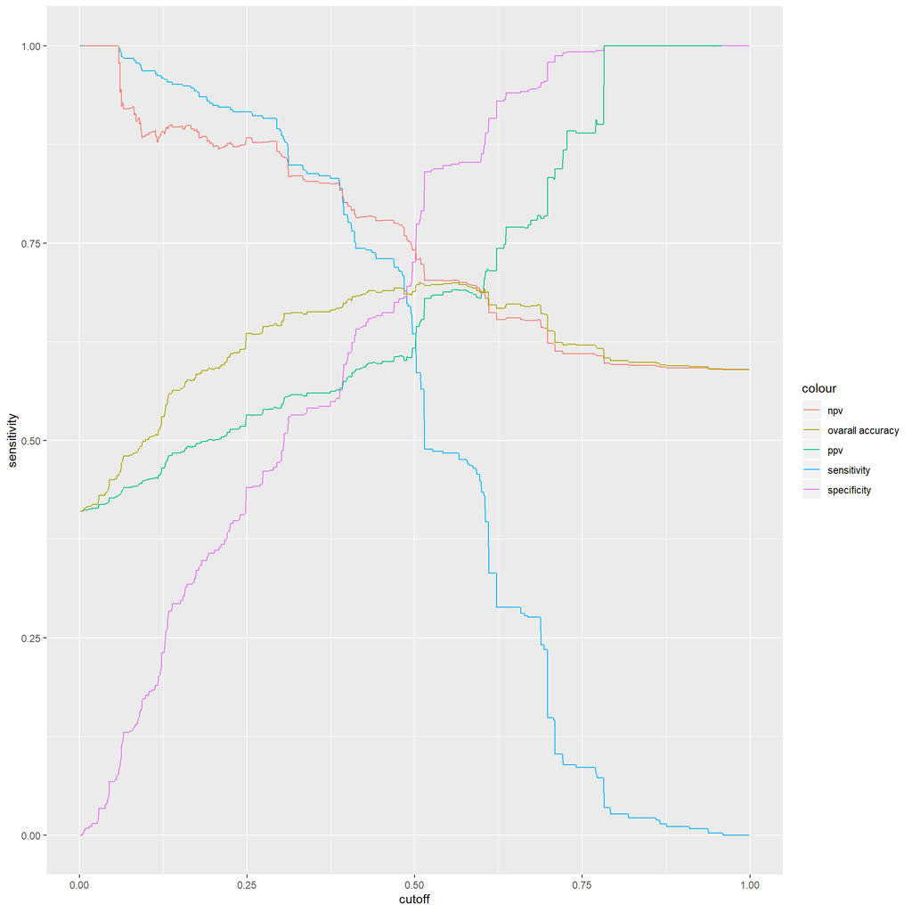

```r
cutoffs <- seq(0.001, 0.999, length.out = 1000)

performance <- list()

for(i in cutoffs) {
  train_df <- train_df %>%
  mutate(prediction_class = factor(ifelse(prediction > i, 1, 0), levels= c(0,1))) %>%
   mutate(presvote_binary = factor(presvote_binary, levels = c(0,1)))

tab <- table(train_df$prediction_class, train_df$presvote_binary)


sensitivity <- round(tab[2,2]/(tab[1,2] +tab[2,2]), 3)
specificity <- round(tab[1,1]/(tab[1,1] +tab[2,1]), 3)
ppv <- round(tab[2,2]/(tab[2,1] +tab[2,2]), 3)
npv <- round(tab[1,1]/(tab[1,1] +tab[1,2]), 3)
ovarall_accuracy <- (tab[1,1] + tab[2,2])/sum(tab)

df <- tibble(cutoff = i,
             ovarall_accuracy = ovarall_accuracy,
             sensitivity = sensitivity,
             specificity = specificity,
             ppv = ppv,
             npv = npv)

performance[[as.character(i)]] <- df
}

performance <- do.call(rbind, performance)

performance %>%
  ggplot(aes(cutoff, sensitivity, color = "sensitivity")) +
  geom_line() +
  geom_line(aes(cutoff, specificity, color = "specificity")) +
  geom_line(aes(cutoff, ppv,color = "ppv")) +
  geom_line(aes(cutoff, npv, color = "npv")) +
  geom_line(aes(cutoff, ovarall_accuracy, color = "ovarall accuracy"))
```

### ROC curve

A curve used extensively in practice is the Receiver Operating Characteristics (ROC) curve. The ROC summarizes performance of the model under all thresholds according to two error metrics; True Positive Rate (Sensitivity) and False Positive Rate (1 - specificity).

```r
library(pROC)

rocobj <- roc(train_df$presvote_binary, train_df$prediction)

g <- ggroc(rocobj)+
    geom_segment(aes(x = 1, xend = 0, y = 0, yend = 1), color="grey", linetype="dashed")

print(rocobj)
```

```
##
## Call:
## roc.default(response = train_df$presvote_binary, predictor = train_df$prediction)
##
## Data: train_df$prediction in 532 controls (train_df$presvote_binary 0) < 370 cases (train_df$presvote_binary 1).
## Area under the curve: 0.7648
```

The overall performance of a classifier, summarized over all possible thresholds, is given by the area under the ROC curve (or AUC). An AUC of .5 indicates a model that does no better than chance. The ROC for a model with a high AUC usually hugs the top left corner of the graph. Our AUC is 0.76, which is somewhere in between a great model and a model that is no better than chance.

#### Aside on performance metrics

When choosing a threshold, not all error metrics are the same. In our toy example here (predicting who a voter will vote for), the consequences of the model making a mistake are quite low. What if our model was trying to predict patient deterioration in hospital?

Let’s say we defined a classifier that predicts which patients will deteriorate in the next 48 hours and may need a transfer to an ICU. When the model predicts that a patient will deteriorate, it sends an alert message to all doctors and nurses caring for this patient. The clinicians then meet to review the patiet’s status and discuss next steps.

These are the errors we can make

- We can predict a patient will deteriorate, and they don’t
- We can predict that a patient will not deteriorate, and they do

We may say, “We don’t want to miss any patients who deteriorate”, so we pick a threshold that gives us a very high sensitivity. This can unintended consequences. If our PPV is too low because we selected a high sensitivity threshold, the clinicians may get too many alarms and start to feel burnout. They may also stop trusting the alarms all together.

The other situtation may be even worse. If we ensure that we have a high PPV, then we may “miss” a bunch of patients who deteriorate. The physicians again will stop trusting the algorithm, and you may not intervene on patients you could have saved.

All this to say that - Non ML/stats experts generally say, give me a model with high accuracy. As we have seen, accuracy can be defined in several different ways. - At the outset of a machine learning project, lay out all of the error metrics and explain to your collaborators the the consequences of each mistake (They may have to explain to you the consequences of each mistake) - Once your collaborators understand what is at stake, you can jointly select performance metrics that satisfies whatever criteria you agree to.